# Inferring the MoA of new drugs through the analysis of heterogeneous response to treatment of different subpopulations of cancer cells

Author

Bastien CHASSAGNOL and Vera PANCALDI and Luca GRUMULATO

Published

3 May 2025

# 1 Introduction: Cell lines DNA Barcoding

- DNA barcoding is also used for inferring the species abundancies in environement samples, just replace the notion of species by cell lines. Similar statistical issues, with *zero-inflated* distributions.
- Steps:
  1. Transfection by virus.
  2. Clonal amplification, unique tagging per cell using MOI.
  3. Clone sizes are assumed to be proportional to the barcode abundances due to this 1-1 mapping of a barcode and a single cell.
- Pros DNA barcoding:
  - Better capture of cell population sizes
  - Better tracking of tagged clones.
- Cons DNA barcoding:
  - Lack of systematic reviews and benchmarks.
  - Mostly rely on bulk RNASeq analytical tools, not accounting for *drop-outs*. In particular, the assumptions that variance across tags is homogeneous, and abundancies follow a negative binomial distribution are quite controversial.

# 2 Reproduce the analyses: setup configuration

I list below the R packages required to reproduce the analyses.

```r
# data wrangling
library(dplyr)
library(tidyr)
library(stringr)
library(readr)
library(readxl)
library(purrr)

# reporting
library(flextable)

# plotting
library(ggplot2)
library(ComplexHeatmap)
library(cowplot)
library(grid)
library(RColorBrewer)
library(igraph)

# auxiliary functions
source("R/utils.R")
today_date <- "2025-04-28"
# today_date <- format(Sys.Date(), "%Y-%m-%d")

# set the seed, for fixing generation of ComplexHeatmaps (dendogram clustering)
set.seed(20)
```

# 3 Data management

- [Original Google Drive repository](https://drive.google.com/drive/folders/1pMSX4M4kHcDGxcsCzsMYHHM6VRvBHHUO).

## 3.1 Experiment selection and formatting

We early discarded `exp130921_in vivo.csv` from the experiences

While the *dose-response* experience `exp200921_dose response osim` exhibits distinct biological objective, it turned out that the 4 control biological replicates are shared with classical compound response comparison `exp200921.csv`. However, **the number of sequenced barcode IDs differ in both experiences!!** In addition, note that `exp200921.csv` has been tagged as discarded, except for the Controls!!

Code snippets in Listing 1 and Listing 2 aim at replacing unprecise labelling of barcode IDs (no concentration, no time duration, …) in the 2022 batch experiences.

Listing 1: Update labelling of latest experience.

```r
# extract old colnames
exp281022_expression <- readr::read_csv("data/barcode-counts/exp281022.csv")
# cat(colnames(exp281022_expression), file = "281022_old_labels.txt", sep = "\n")

# extract mapping old_names with new_names
mapping_old_new_281022 <- readxl::read_excel("data/Table of compounds_whole_2025-04-28.xlsx",
                                             sheet = "Sample Mapping 281022")

labels_old_new_281022 <- setNames(object = mapping_old_new_281022$OLD_replicate_label,
                                  nm = mapping_old_new_281022$NEW_replicate_label)

# apply change labelling
exp281022_expression <- exp281022_expression |>
  dplyr::rename(dplyr::all_of(labels_old_new_281022))

readr::write_csv(exp281022_expression, "data/barcode-counts/exp281022.csv")
```

Listing 2: Update time course experiences.

```r
exp281022_expression_timecourse <- readr::read_csv("data/barcode-counts/exp281022_time course.csv")
# cat(colnames(exp281022_expression_timecourse), file = "281022_timecourse_old_labels.txt", sep = "\n")

# update colnames ----

mapping_old_new_time_course <- read_excel("data/Table of compounds_whole_2025-04-28.xlsx",
                                     sheet = "Sample Mapping Time Course")

labels_old_new_time_course <- setNames(object = mapping_old_new_time_course$OLD_replicate_label,
                                       nm = mapping_old_new_time_course$NEW_replicate_label)

# apply change labelling
exp281022_expression_timecourse <- exp281022_expression_timecourse |>
  dplyr::rename(dplyr::all_of(labels_old_new_time_course))

readr::write_csv(exp281022_expression_timecourse,
                 "data/barcode-counts/exp281022_time course.csv")

# To evaluate whether controls are different between experiment 281022 and 281022 Time Course
controls_exp281022 <- exp281022_expression |>
  select(key_barcode, dplyr::matches("^ctl")) |>
  dplyr::inner_join(exp281022_expression_timecourse |>
                      select(key_barcode, dplyr::matches("^Ctrl")),
                    by="key_barcode")
cor(controls_exp281022$ctl2, controls_exp281022$Ctrl2) # they strongly correlate with each other, but not a perfect match -> controls are indeed distinct
```

### 3.1.1 TODO: barcode counts inconsistencies

Things to consider:

- Format used is **French csv**, instead of international CSV. CSV means for ‘comma-separated value’, maybe consider switching [Excel settings](https://support.microsoft.com/en-us/office/import-or-export-text-txt-or-csv-files-5250ac4c-663c-47ce-937b-339e391393ba).
- I rename the first colname of each expression file as `barcode_id`, storing unequivocal tag.
- Some barcode counts exhibit final line `index`, for which reason?

### 3.1.2 Overview of barcode counts

We report in Table 1 a summary of the barcode counts (File location, `batch_id`, and dimensions of the counts matrix) considered for the generation of the Heatmaps, and the construction of a drug-drug network.

```r
# 1) summarise kept batches ----
barcode_files <- list.files("./data/barcode-counts/",
                            pattern = "exp.*\\.csv",
                            full.names = TRUE)

kept_barcode_summaries <- purrr::map(barcode_files, function(filename) {
  barcode_counts <- readr::read_csv(filename, show_col_types = FALSE)
  experience_name <- filename |> basename() |> tools::file_path_sans_ext()
  experience_summary <- tibble::tibble(`Experience Name`= experience_name,
                                       Features= paste0("Barcode matrix contains: ",
                                                        nrow(barcode_counts),
                                                        " unique barcode IDs, and ",
                                                        ncol(barcode_counts)-1, " replicates."))
  return(experience_summary)
}) |>
  purrr::list_rbind()
flextable::flextable(kept_barcode_summaries) |>
  bold(part="header")
# 2) summarise discarded batches ----
discarded_files <- list.files("./data/barcode-counts/temp discarded/",
                            pattern = "exp.*\\.csv",
                            full.names = TRUE)

# change format + barcode name
barcode_discarded_summaries <- purrr::map(discarded_files, function(filename) {
  barcode_counts <- readr::read_csv(filename, show_col_types = FALSE)
  experience_name <- filename |> basename() |> tools::file_path_sans_ext()
  experience_summary <- tibble::tibble(`Experience Name`= experience_name,
                                       Features= paste0("Barcode matrix contains: ",
                                                        nrow(barcode_counts),
                                                        " unique barcode IDs, and ",
                                                        ncol(barcode_counts)-1, " replicates."))
  return(experience_summary)
}) |>
  purrr::list_rbind()

flextable::flextable(barcode_discarded_summaries) |>
  bold(part="header")
```

| Experience Name | Features |
| --- | --- |
| exp010821 | Barcode matrix contains: 869714 unique barcode IDs, and 16 replicates. |
| exp040821 | Barcode matrix contains: 869714 unique barcode IDs, and 16 replicates. |
| exp070222 | Barcode matrix contains: 93132 unique barcode IDs, and 68 replicates. |
| exp130921 | Barcode matrix contains: 627539 unique barcode IDs, and 24 replicates. |
| exp151121 | Barcode matrix contains: 844434 unique barcode IDs, and 60 replicates. |
| exp181021 | Barcode matrix contains: 813579 unique barcode IDs, and 59 replicates. |
| exp200921 | Barcode matrix contains: 627539 unique barcode IDs, and 40 replicates. |
| exp200921_dose response osim | Barcode matrix contains: 1067031 unique barcode IDs, and 20 replicates. |
| exp220322 | Barcode matrix contains: 93132 unique barcode IDs, and 66 replicates. |
| exp271221 | Barcode matrix contains: 844434 unique barcode IDs, and 80 replicates. |
| exp281022 | Barcode matrix contains: 315642 unique barcode IDs, and 22 replicates. |
| exp281022_time course | Barcode matrix contains: 398004 unique barcode IDs, and 51 replicates. |
| exp300821 | Barcode matrix contains: 413335 unique barcode IDs, and 28 replicates. |

(a) Kept Batches

[output not shown]

(b) Removed batches

Table 1: Overview of the Barcoding Batches.

In **?@tbl-overview-barcode-samples**, 13 barcode experiences were included in the analysis, whereas 2 batches/experiences were not included.

## 3.2 Phenotypes

- General question: what’s the difference between `Run Date` and `Experiment Date`?

Most of the R instructions reported in this section aim at rendering the `Table of compounds` file compliant with the `tidy` format, see Tip 1. These data-wrangling operations are split in 4 steps:

1. In Listing 3, we homogenise `Concentrations`, `Date` and `Duration` to ISO standards, while dealing with erroneous missing values generated by fused Excel cells. Besides, we removed special, non-ascii characters that could not be processed by visualisation plots, such as $NF-\kappa B$.
2. In Listing 4, we retrieve from each individual barcode counts profile, the individual replicates ID identifying unequivocally each replicate. We set apart replicates that could be mapped back to original `Table of compounds` file.
3. In Listing 5, we merge together in a comprehensive phenotype table the short `Samples_ID` (short term referring to drugs listed in `Compound` column), the full `Compound` (complete name of drugs) and map each of them to its complete list of replicates (from 2 to 8). We save the output in `data-derived`.
4. Finally, in Listing 6 and Listing 7, we perform several posterior *data integrity checks* to verify if i) we were able to map each individual replicate ID to its original ID in `Table of compounds`, and ii) if the number of replicates reported in `Table of compounds` was consistent with the number of barcode profiles.

Listing 3: Coerce original Excel file reporting experimental design to tidy format.

```r
pheno_colnames <- c(Pathway = "Pathways", MoA = "...2",
                    Compound = "Samples", Replicates = "Replicates",
                    Concentrations = "Concentrations", Date = "Experiment date",
                    `Run date` = "Run date", Duration="Duration",
                    Kept="Kept", Comments = "Comments")

# prune irrelevant colnames ----
# data/Table of compounds_stringent_2025-04-18.xlsx
pheno_data <- readxl::read_xlsx("data/Table of compounds_whole_2025-04-28.xlsx",
                                sheet = "Experimental Design",
                                col_types = c(rep("text", 3), "numeric",
                                              rep("text", 4), "logical", "text")) |>
  dplyr::rename(dplyr::all_of(pheno_colnames)) |>
  tidyr::fill(Pathway, MoA, .direction = "down")

pheno_data_discarded <- pheno_data |>
  dplyr::filter(!Kept)

# Add batches and correct for fused Excel cells ----

pheno_data <- pheno_data |>
  # extract last 6 numbers
  dplyr::mutate(Compound = if_else(grepl("Control", MoA, ignore.case = TRUE),
                                  MoA, Compound),
                `Run date` = stringr::str_sub(`Run date`, -6, -1),
                Batch_ID= paste0("exp", Date)) |>
  tidyr::fill(Compound, .direction = "down") |>
  # remove unwanted replicates
  dplyr::filter(Kept) |>
  dplyr::mutate(Batch_ID = dplyr::if_else(Comments %in% c("Dose Response"),
                                          "exp200921_dose response osim", Batch_ID)) |>
  dplyr::mutate(Batch_ID = dplyr::if_else(Comments %in% c("Time Course"),
                                          "exp281022_time course", Batch_ID),
                Pathway = if_else(is.na(Pathway), MoA, enc_to_ascii(Pathway))) |>
  dplyr::select(- Comments, -Kept) |>
  dplyr::distinct(.keep_all = TRUE) # remove duplicates

# format concentrations, creating both 'Concentrations_ID' and 'Concentrations' in Moles ----
pheno_data <- pheno_data |>
  dplyr::mutate(Concentrations=if_else(Compound=="Control", "000 uM", Concentrations)) |>
  dplyr::mutate(Concentrations=if_else(Compound=="Osimertinb+sorafenib", "015 uM", Concentrations)) |>
  tidyr::separate_wider_delim(Concentrations, delim = " ", names = c("Concentrations Value", "Unit"), cols_remove = FALSE) |>
  dplyr::rename(OLD_Concentrations=Concentrations) |>
  dplyr::mutate(Unit = case_when(
    Unit %in% c("uM", "µM", "µg/ml") ~ "u",
    Unit == "nM" ~ "n",
    Unit %in% c("mg/kg", "mM") ~ "m",
  )) |>
  dplyr::mutate(Concentrations=parse_number(`Concentrations Value`, trim_ws = TRUE,
                                            locale = locale(decimal_mark = ",", grouping_mark = "."))) |>
   dplyr::mutate(Concentrations = case_when(
    Unit == "u" ~ Concentrations *10^-6,
    Unit == "n" ~ Concentrations *10^-9,
    Unit == "m" ~ Concentrations *10^-3)) |>
  dplyr::mutate(`Concentrations Value`=parse_number(`Concentrations Value`, trim_ws = TRUE,
                                            locale = locale(decimal_mark = ",", grouping_mark = ".")) |>
                  format_concentrations()) |>
  tidyr::unite(col ="Concentrations_ID", `Concentrations Value`, Unit, sep = "")

# format Durations, creating both 'Duration_ID' and 'Duration' as an integer value in Days ----
pheno_data <- pheno_data |>
  # extract last 6 numbers, as the only ones used for identification of samples downstream
  dplyr::mutate(Duration_ID = Duration,
                Duration = parse_number(Duration, trim_ws = TRUE,
                                        locale = locale(decimal_mark = ".")),
                Duration = dplyr::if_else(grepl("m$",  Duration_ID),
                                          Duration*30, Duration))
```

**Metadata inconsistencies and Conversion to UIC Units**

- In `Run date`, when there was a range instead of a fixed Date, I kept only the end of the interval, as used for labelling colnames in barcode counts.
- Homogenise units for the `Concentrations` colname: convert everything to moles.
- Homogenise units for `Date` and `Run date`, using international ISO 8601 format: `YYYY-MM-DD`

In Listing 4 and Listing 5, we identify which raw barcode counts matrices avalaible in folder `barcode-counts` are not reported in the global experimental dataset, and reciprocally. Finally, we only **keep experiences that are both reported in `Table of compounds` and present in `barcode-counts` folder.**.

Listing 4: Identify shared experience IDs between experimental design table (`Table of compounds`), and barcode-count counts profiles.

```r
# keep only relevant files
barcodes_filenames <- list.files("./data/barcode-counts/",
                                pattern = "^exp.*\\.csv$")

barcodes_IDs <- readxl::read_xlsx("data/Table of compounds_whole_2025-04-28.xlsx",
                                       sheet="Batch Mapping") |>
  select(Filename, Batch_ID) |>
  filter(!Batch_ID %in% c("exp130921_in vivo")) |>
  mutate(Filename =paste0(Filename, ".csv"),
         Date = stringr::str_extract(Batch_ID, "(?<=^exp)[[:digit:]]{6}"))
```

To generate the final phenotype dataset, we only keep experiences that were reported both in `Table of Compound` and folder `barcode-counts` in Listing 5. **Please ensure that `Drugs Mapping` sheet in `Table of compounds` is correct.**

Listing 5: Map each compound to its full list of replicates. Generate a `Batch_ID` to unequivocally ientify each run of experiences, and convert all run Dates to their international format.

```r
# step 1) keep only shared Batch_ID experiences ----
barcodes_IDs <- barcodes_IDs |>
  dplyr::semi_join(pheno_data, by="Batch_ID")
# exp201021 is discarded, that's normal, we just want to keep the controls!!
pheno_data <- pheno_data |>
  dplyr::semi_join(barcodes_IDs, by="Batch_ID")

# step 2) extract individual replicate IDs directly from sample experiences ----
# Filename <- "exp281022.csv"; Batch_ID <- "exp281022"; Date <- "281022"
ID_mapping <- purrr::pmap(barcodes_IDs, function(Filename, Batch_ID, Date) {
  # build path
  counts_path <- file.path("data","barcode-counts",
                               paste0(Filename))

  # extract replicate names (reading the header)
  replicates_ID <- strsplit(readLines(counts_path, n = 1), split = ",")[[1]] |>
    str_subset("\\S") |> # remove empty strings and 'key'
    str_subset("barcode_id", negate = TRUE)

  # ID: combination of letters, numbers and -, followed by '[1-4]_', starting the sample's name
  dataset_ID <- tibble::tibble(Batch_ID = Batch_ID,
                               Date = stringr::str_extract(replicates_ID,
                                                           "(?<=_exp)[[:alnum:]]{6}"),
                               Replicates_ID = replicates_ID,
                               `Run date` = stringr::str_extract(replicates_ID,
                                                                 "(?<=_run)[[:alnum:]]{6}(?=_)"),
                               Concentrations_ID = stringr::str_extract(replicates_ID,
                                                                        "(?<=[1-8]_)[[:digit:]]{3}[gmnux]{1}(?=_exp)")) |>
    # account for second notation syntax for concentrations
    dplyr::mutate(Concentrations_ID = if_else(is.na(Concentrations_ID),
                                              stringr::str_extract(replicates_ID,
                                                                   "(?<=[1-8]_)[0-9]{1}\\.[0-9]{2}[gmnux]{1}(?=_exp)"),
                                              Concentrations_ID))

  # Deal with two time notations
  if (grepl("Time",Batch_ID, ignore.case = TRUE)) {
    dataset_ID <- dataset_ID |>
      dplyr::mutate (Samples_ID = stringr::str_extract(replicates_ID,
                                                       "(?<=_)[[[:alnum:]]\\-]+(?=[1-8]_)"),
                     Duration_ID=stringr::str_extract(replicates_ID,
                                                       "^[[[:alnum:]]\\.]{1,3}[dm](?=_)"))
  }
  else {
      dataset_ID <- dataset_ID |>
      dplyr::mutate (Samples_ID = stringr::str_extract(replicates_ID,
                                                       "^[[[:alnum:]]\\-]+(?=[1-8]{1}_)"),
                     Duration_ID="9d")
  }

  return(dataset_ID)
}) |>
  purrr::list_rbind()

# deal with specific p42 and p43
ID_mapping <- ID_mapping |>
  dplyr::mutate(Samples_ID = if_else(grepl("^p42", Replicates_ID), "p42", Samples_ID),
                Samples_ID = if_else(grepl("^p43", Replicates_ID), "p43", Samples_ID))

# remove irrelavant samples
ID_mapping <- ID_mapping |>
  dplyr::filter(!grepl("^p42|^p43|^CTRL", Replicates_ID))


# detect miscatech samples
# ID_mapping_missing <- ID_mapping |>
#   filter(if_any(everything(), is.na))

# step 3) map short compound IDs with full compound names ----
mapping_compounds <- readxl::read_xlsx("data/Table of compounds_whole_2025-04-28.xlsx",
                                sheet = "Drugs Mapping")
ID_mapping <- ID_mapping |>
  inner_join(mapping_compounds, by = "Samples_ID")
# test <- ID_mapping |> anti_join(mapping_compounds, by = "Samples_ID")
# test2 <- mapping_compounds |> anti_join(ID_mapping, by = "Samples_ID")
```

Finally, in Listing 6, we map all replicates (one column in a given barcode count matrix) to its comprehensive metadata descripion (stored in `Tables of compounds`), using as **primary and foreign keys** the following 6 variables: `Batch_ID`, `Compound`, `Duration_ID`, `Run date`, `Date`, and `Concentrations_ID`.

Listing 6: Extract discarded replicates

```r
replicates_discarded <- dplyr::anti_join(ID_mapping, pheno_data,
                                     by = c("Batch_ID",  "Compound", "Duration_ID",
                                            "Run date", "Date", "Concentrations_ID"))

pheno_data_unmapped <- dplyr::anti_join(pheno_data,
                                     ID_mapping,
                                     by = c("Batch_ID",  "Compound", "Duration_ID",
                                            "Run date", "Date", "Concentrations_ID"))

pheno_data_unmapped |>
  arrange(Compound, Date, Concentrations_ID) |>
  flextable() |>
  bold(part = "header")
```

| Pathway | MoA | Compound | Replicates | Concentrations_ID | OLD_Concentrations | Date | Run date | Duration | Batch_ID | Concentrations | Duration_ID |
| --- | --- | --- | --- | --- | --- | --- | --- | --- | --- | --- | --- |

Table 2: Identify set of experiences reported in `Table of compounds` that could not be mapped against their corresponding Barcode counts replicates. We check this information with an `anti_join` between original *phenotype* and *counts*, returning samples from `Table of Compound` that could not have been mapped back.

In Table 3, we check discrepancies between the number of barcode replicates reported in `Table of compounds` with the number of replicates avalaible in barcode counts matrices. And it turned out that `compound`: XAV-939, `Date`: 220322, is reported with 4 replicates, while only 2 could be found in `exp220322` barcode count matrix

Listing 7: Secound round of data wrangling quality controls on *counts* versus *phenotype data*, focusing on divergent number of replicates.

```r
replicate_inconsistencies <- pheno_data |>
  dplyr::inner_join(ID_mapping,
                    by = c("Batch_ID", "Date",
                           "Compound", "Run date",
                           "Concentrations_ID", "Duration_ID")) |>
  group_by(Batch_ID, Compound, Date, Replicates, Concentrations_ID,Duration_ID) |>
  summarise(n=n()) |>
  filter(n!=Replicates)

flextable(replicate_inconsistencies) |>
  autofit() |>
  bold(part = "header")
```

| Batch_ID | Compound | Date | Replicates | Concentrations_ID | Duration_ID | n |
| --- | --- | --- | --- | --- | --- | --- |
| exp220322 | XAV-939 | 220322 | 4 | 080u | 9d | 2 |

Table 3: Secound round of data wrangling quality controls on *counts* versus *phenotype data*, focusing on divergent number of replicates.

### 3.2.1 Save phenotype Metadata

By applying all the formatting analyses reported in Section 3.2, we generate in Table 4 a global metadata phenotypic table, adhering to tidy principles Tip 1.

**Tip 1: Tidy Data Format (Key Principles)**

1. **Each variable has its own column**.
2. **Each observation has its own row** – Every row corresponds to one observation.
3. **Each value has its own cell** – Each cell contains a single, unique value.

This format streamlines data wrangling, and generally speaking, data analysis and visualisation. In other words, prefer simpler `CSV` formats for the experimental design, and avoid *cell fusion* in Excel documents. Finally, for the formatted tabular representation in documentations, I use `flextable`.

Listing 8: Save the final metadata annotations for barcodes, using Today’s date for historical versioning.

```r
# step 4) Use international date formats ----
pheno_data_formatted <- pheno_data |>
  dplyr::inner_join(ID_mapping,
                    by = c("Batch_ID", "Date",
                           "Compound", "Run date",
                           "Concentrations_ID", "Duration_ID")) |>
  dplyr::select(Batch_ID, Pathway, MoA,
                Compound, Samples_ID,
                Replicates, Replicates_ID,
                Concentrations, Concentrations_ID,
                Date, `Run date`, Duration, Duration_ID) |>
  # convert to ISO 1860 Date format
  mutate(Date = lubridate::dmy(Date) |> format(),
         `Run date`= lubridate::dmy(`Run date`),
  # artifically de-duplicate controls for exp, simplify the analytical workflow
  Replicates_ID = dplyr::if_else(Batch_ID %in% c("exp200921_dose response osim") &
                                   Compound=="Control",
                                 gsub("exp200921_", "exp200921_dose_response_", Replicates_ID),
                                 Replicates_ID))

# 2) QC: guarantee uniqueness of the replicates
pheno_data_deduplicated <- pheno_data_formatted |>
  dplyr::distinct(Replicates_ID, .keep_all = TRUE)
all.equal(pheno_data_deduplicated, pheno_data_formatted)
```

```
[1] TRUE
```

Listing 9: Save the final metadata annotations for barcodes, using Today’s date for historical versioning.

```r
# 3) save as .xlsx file discarded and preserved replicates

barcode_counts_summaries <- list("kept counts" = kept_barcode_summaries,
                                 "kept compounds" = pheno_data,
                                 "kept replicates" = pheno_data_formatted |>
                                   select(Compound, Replicates_ID),
                                 "discarded counts" = barcode_discarded_summaries,
                                 "discarded compounds"=pheno_data_discarded,
                                 "discarded replicates" = replicates_discarded)

openxlsx::write.xlsx(x = barcode_counts_summaries,
                     file = paste0("./data/logs/barcode_metadata_overview_",
                                   today_date,".xlsx"),
                     overwrite = TRUE, asTable = TRUE)


# 4) save the tidy phenotype metatada table ----
readr::write_csv(pheno_data_formatted,
                 file = paste0("data/pheno_data_metadata_", today_date,".csv"))

flextable::flextable(head(pheno_data_formatted)) |>
  autofit() |>
  bold(part="header")
```

| Batch_ID | Pathway | MoA | Compound | Samples_ID | Replicates | Replicates_ID | Concentrations | Concentrations_ID | Date | Run date | Duration | Duration_ID |
| --- | --- | --- | --- | --- | --- | --- | --- | --- | --- | --- | --- | --- |
| exp010821 | Control | Control | Control | Contro | 4 | Contro1_000u_exp010821_run180821_03 | 0 | 000u | 2021-08-01 | 2021-08-18 | 9 | 9d |
| exp010821 | Control | Control | Control | Contro | 4 | Contro2_000u_exp010821_run180821_04 | 0 | 000u | 2021-08-01 | 2021-08-18 | 9 | 9d |
| exp010821 | Control | Control | Control | Contro | 4 | Contro3_000u_exp010821_run180821_05 | 0 | 000u | 2021-08-01 | 2021-08-18 | 9 | 9d |
| exp010821 | Control | Control | Control | Contro | 4 | Contro4_000u_exp010821_run180821_06 | 0 | 000u | 2021-08-01 | 2021-08-18 | 9 | 9d |
| exp040821 | Control | Control | Control | Contro | 4 | Contro1_000u_exp040821_run180821_25 | 0 | 000u | 2021-08-04 | 2021-08-18 | 9 | 9d |
| exp040821 | Control | Control | Control | Contro | 4 | Contro2_000u_exp040821_run180821_26 | 0 | 000u | 2021-08-04 | 2021-08-18 | 9 | 9d |

Table 4

**Conclusion**: on a total of 544, 532 replicates are kept, and 12 replicates were removed[^1].

# 4 Methods

## 4.1 Preprocessing barcode counts

**Code colour**: Luca’s protocol, and Bastien’s comments and perspectives

### 4.1.1 **Background Noise Removal** and `SummarizedExperiment` stantardised storage

Listing 10: Remove background noise.

```r
barcode_files <- list.files("./data/barcode-counts/",
                            pattern = "exp.*\\.csv",
                            full.names = TRUE)
thresh_background <- 4
# ./data/pheno_data_metadata_2025-04-18.csv
pheno_data <- readr::read_csv(paste0("./data/pheno_data_metadata_",
                                     today_date, ".csv"))

# filename <- grep( "exp200921", barcode_files, value = TRUE)[2]
barcode_counts_aggregated <- purrr::map(barcode_files, function(filename) {
  barcode_counts <- readr::read_csv(filename)
  experience_name <- filename |> basename() |> tools::file_path_sans_ext()

  # 1) explicitly change replicates name to enable 1-1 mapping ----
  if (experience_name=="exp200921_dose response osim") {
    barcode_counts <- barcode_counts |>
      dplyr::rename_with(
        .fn = ~ gsub("exp200921_", "exp200921_dose_response_", .x),
        .cols = starts_with("Contro"))
  }
  replicates_names <- setdiff(colnames(barcode_counts), "barcode_id")

  # 2) Remove lowly expressed barcodes ----
  control_index <- pheno_data |>
    dplyr::filter(Batch_ID==experience_name &
                    Compound=="Control" &
                    Replicates_ID %in% replicates_names) |>
    dplyr::pull(Replicates_ID)
  signicant_barcodes_index <- which(rowSums(barcode_counts[, control_index]) > thresh_background)
  filtered_barcode_counts <- barcode_counts[signicant_barcodes_index,]

  message(paste("\n\nWe are considering experiment:", experience_name, "with", nrow(filtered_barcode_counts), "barcode IDs kept.\n\n"))

  return(filtered_barcode_counts)
}) |>
  purrr::reduce(~ inner_join(.x, .y, by = "barcode_id"))

# Deal with specific duplicated colnames, resulting from control duplicates
# barcode_counts_aggregated <- barcode_counts_aggregated |>
#   dplyr::select(!ends_with(".y")) |>
#   dplyr::rename_with(.fn = ~ gsub("\\.x$", "", .x),
#                      .cols = dplyr::ends_with(".x"))

# 3) keep only replicates present in pheno_data
barcode_counts_aggregated <- barcode_counts_aggregated |>
  select(all_of(c("barcode_id", pheno_data$Replicates_ID)))
```

- After filtering for background noise, and merging all experiences based on shared barcode IDs, 4629 unique barcode IDs are kept, for 532 samples, see Listing 10 for details.
- Density plot of controls + justify why + check absence of outliers, to evaluate the relevance of this threshold, `HTSFilter`, comparison with existing filtering approaches.

### 4.1.2 **Normalisation**

- Normalize barcodes so that the total number of counts per sample is equal to `100,000`. This operation is performed in Listing 11.

Listing 11: Normalise by $100000$.

```r
# 1) normalise by total number of counts ----
barcode_counts_normalised <- barcode_counts_aggregated |>
  mutate(across(
    .cols = where(is.numeric),
    .fns = ~ (.x / sum(.x)) * 1e5))
```

- Close to two existing normalisation methods: **Counts Per Million (CPM)** which additionally scales raw counts by total library size and multiplies by $1,000,000$ and **Total Count Scaling (TCS)**: Scales raw counts by the total number of reads (or mapped reads) in each sample, then multiplies by a fixed number (e.g., 100,000). Would compare other normalisation approaches + ignore biological or technical biases + generate MA plots for verifying the mean-variance correction trend + not suitable for DEGs analyses. Apply concatenation phase of all samples before normalising. [Preprocessing and normalisation functions for transcriptomics: a general overview](https://www.linkedin.com/posts/%F0%9F%8E%AF-ming-tommy-tang-40650014_rna-seq-normalization-what-you-need-to-activity-7313919533780516864-6jFm)

### 4.1.3 Prepare `SummarizedExperiment` objects for normalised data

- Higher level of granularity in Listing 12:

Listing 12: Simply compute the Pearson correlation score at the replicate level, and save the output as a `SummarizedExperiment`.

```r
# 2) prepare SummarizedExperiment inputs ----
# Barcode counts at replicate level
barcode_normalised_replicates_mat <- barcode_counts_normalised |>
                  tibble::column_to_rownames("barcode_id") |>
                  as.matrix()

# Sample metadata
pheno_data_replicates <- pheno_data |>
  tibble::column_to_rownames("Replicates_ID")

# Feature metadata
barcode_metadata <- tibble::tibble(barcode_id = barcode_counts_normalised$barcode_id)
row.names(barcode_metadata) <- barcode_metadata$barcode_id

# 3) Buid and Save SummarizedExperiment
se_replicates <- SummarizedExperiment::SummarizedExperiment(
  assays = list(counts = barcode_normalised_replicates_mat),
  rowData = barcode_metadata,
  colData = pheno_data_replicates)
```

- Medium level of granularity in Listing 13, averaging over replicates:

Listing 13: Simply compute the Pearson correlation score at the Compound per Batch level.

```r
barcode_counts_long <- barcode_counts_normalised |>
  tidyr::pivot_longer(-barcode_id,
                      names_to = "Replicates_ID",
                      values_to = "Barcode_Counts") |>
  dplyr::inner_join(pheno_data, by="Replicates_ID")

barcode_counts_wider_compound_batch <- barcode_counts_long |>
  tidyr::pivot_wider(id_cols = c(barcode_id),
                     names_from = c(Batch_ID, Compound, Concentrations_ID, Duration_ID),
                     names_sep = ":",
                     values_from = Barcode_Counts,
                     values_fn=mean)

pheno_compound_batch <- tibble::tibble(original =setdiff(colnames(barcode_counts_wider_compound_batch),"barcode_id")) |>
  mutate(Batch_ID = stringr::str_split_i(original, ":", 1),
         Compound = stringr::str_split_i(original, ":", 2),
         Concentrations_ID = stringr::str_split_i(original, ":", 3),
         Duration_ID = stringr::str_split_i(original, ":", 4)) |>
  inner_join(pheno_data |> select(Batch_ID, Pathway, MoA, Compound,
                                  Concentrations, Concentrations_ID, Duration, Duration_ID),
             by = c("Batch_ID", "Compound", "Concentrations_ID", "Duration_ID")) |>
  dplyr::distinct() |>
  dplyr::select(-Concentrations_ID, -Duration_ID) |>
  tibble::column_to_rownames("original")

se_compound_batch <- SummarizedExperiment::SummarizedExperiment(
  assays = list(counts = barcode_counts_wider_compound_batch |>
                  tibble::column_to_rownames("barcode_id") |>
                  as.matrix()),
  rowData = barcode_metadata,
  colData = pheno_compound_batch)
```

- Low level of granularity in Listing 14, with one CC per compound:

Listing 14: Compute the Pearson correlation score, after averaging the barcode counts per compound.

```r
barcode_counts_wider_by_compound <- barcode_counts_long |>
  tidyr::pivot_wider(id_cols = c(barcode_id),
                     names_from = c(Compound),
                     values_from = Barcode_Counts,
                     values_fn=mean)

pheno_compound <- tibble::tibble(Compound = setdiff(colnames(barcode_counts_wider_by_compound), "barcode_id")) |>
  inner_join(pheno_data |> select(Pathway, MoA, Compound),
             by = c("Compound")) |>
  dplyr::distinct() |>
  tibble::column_to_rownames("Compound")

se_compound <- SummarizedExperiment::SummarizedExperiment(
  assays = list(counts = barcode_counts_wider_by_compound |>
                  tibble::column_to_rownames("barcode_id") |>
                  as.matrix()),
  rowData = barcode_metadata,
  colData = pheno_compound)
```

```r
saveRDS(se_replicates, file = paste0("./results/compounds/se_normalised_per_replicate_",
                          today_date, ".rds"))
saveRDS(se_compound_batch, file = paste0("./results/compounds/se_normalised_per_compound_by_batch_",
                          today_date, ".rds"))
saveRDS(se_compound, file = paste0("./results/compounds/se_normalised_per_compound_",
                          today_date, ".rds"))
```

## 4.2 **Differential analyses** and Binarisation

Listing 15: Compute the averaged value for control replicates, then binarise for each compound. A `1` denoting a significant positive enrichment for a given `barcode_id`.

```r
# Step 1: Compute control means per barcode_id and Batch ----
threshold_FC <- 3
control_means <- barcode_counts_long |>
  filter(Compound == "Control") |>
  group_by(Batch_ID, barcode_id) |>
  summarise(Control_Mean = mean(Barcode_Counts), .groups = "drop")

# Step 2: Join control mean to full dataset ----
barcode_discretised_replicates <- barcode_counts_long |>
  left_join(control_means,
            by = c("Batch_ID","barcode_id"))

# Step 3: Compute Fold Change and discretise ----
barcode_discretised_replicates <- barcode_discretised_replicates |>
  filter(Compound != "Control") |>
  mutate(Diff = Barcode_Counts - Control_Mean,
    Barcode_Counts = if_else(Diff > threshold_FC, 1, 0)) |>
  # Final cleanup
  select(-Diff, -Control_Mean)  |>
  dplyr::mutate(Barcode_Counts = as.logical(Barcode_Counts))
```

Batch effect correction for integrating across batches? // As Vera emphasised it out, why keeping only positive values? Negative are also interesting. Why not pairing $p$-values and fold-change (considering indeed really small sample sizes)? // All these operations can be performed with one run, using `lm`, and a model as such, $\text{Expr} \sim 0 + \text{Gene} + \text{Batch} + \text{Drug}$, with a `contr.treatment` design matrix // Perform **sensitivity analyses** to evaluate the impact of threshold criteriaon for binarisation on downstream analyses. [^3].

### 4.2.1 `SummarizedExperiment` of binarised markers

- `SummarizedExperiment` at the replicates level (controls being discarded)

```r
# Step 4: Save as a SummarizedExperiment ----
barcode_discretised_replicates_mat <- barcode_discretised_replicates |>
  tidyr::pivot_wider(id_cols = barcode_id, names_from = Replicates_ID, values_from = Barcode_Counts)

pheno_replicates_discretised <- pheno_data |>
  dplyr::filter(Replicates_ID %in% barcode_discretised_replicates$Replicates_ID) |>
  tibble::column_to_rownames("Replicates_ID")

se_discretised_replicates <- SummarizedExperiment::SummarizedExperiment(
  assays = list(binarised = barcode_discretised_replicates_mat |>
                  tibble::column_to_rownames("barcode_id") |>
                  as.matrix()),
  rowData = barcode_metadata,
  colData = pheno_replicates_discretised)

saveRDS(se_discretised_replicates,
        file = paste0("./results/compounds/se_discretised_per_replicate_",
                      today_date, ".rds"))
```

- Logical `AND` over replicates: drug by batch (and concentration and time).

Listing 16: Average the replicates, using a `all` operator.

```r
# 2) discretised correlation at the compound by batch level (averaging over replicates), with an all function
barcode_discretised_compound_batch <- barcode_discretised_replicates |>
   tidyr::pivot_wider(id_cols = c(barcode_id),
                     names_from = c(Batch_ID, Compound, Concentrations_ID, Duration_ID),
                     names_sep = ":",
                     values_from = Barcode_Counts,
                     values_fn=all)

pheno_discretised_compound_batch <- pheno_compound_batch[setdiff(colnames(barcode_discretised_compound_batch), "barcode_id"), ]

se_compound_batch_discretised <- SummarizedExperiment::SummarizedExperiment(
  assays = list(discretised = barcode_discretised_compound_batch |>
                  tibble::column_to_rownames("barcode_id") |>
                  as.matrix()),
  rowData = barcode_metadata,
  colData = pheno_discretised_compound_batch)

saveRDS(se_compound_batch_discretised,
        file = paste0("./results/compounds/se_discretised_per_compound_by_batch_",
                      today_date, ".rds"))
```

- Average over compounds.

Listing 17: Aggregate at the compound level, assigning a 1 if barcode cell lines were found positiveliy enriched in all compounds.

```r
# 2) discretised correlation at the compound by batch level (averaging over replicates), with an all function
barcode_discretised_compound <- barcode_discretised_replicates |>
   tidyr::pivot_wider(id_cols = c(barcode_id),
                     names_from = c(Compound),
                     names_sep = ":",
                     values_from = Barcode_Counts,
                     values_fn=all)

pheno_discretised_compound<- pheno_compound[setdiff(colnames(barcode_discretised_compound), "barcode_id"), ]

se_compound_discretised <- SummarizedExperiment::SummarizedExperiment(
  assays = list(discretised = barcode_discretised_compound |>
                  tibble::column_to_rownames("barcode_id") |>
                  as.matrix()),
  rowData = barcode_metadata,
  colData = pheno_discretised_compound)

saveRDS(se_compound_discretised,
        file = paste0("./results/compounds/se_discretised_per_compound_",
                      today_date, ".rds"))
```

# 5 Results

## 5.1 Compute Compound Similarities

- Actual computation of the correlation matrix using `stats::cor`.
- Yet, we have to try other correlation methods on the continuous space, or consider other metrics if working on the discrete space. Unbalanced Wassertein distance, or relatives, for distinct input and output dimensions.

### 5.1.1 Compound Heatmaps

- Some tutorials:
  - [Blend of useful resources on generating Heatmaps](https://www.linkedin.com/posts/%F0%9F%8E%AF-ming-tommy-tang-40650014_making-a-heatmap-is-an-essential-skill-for-activity-7317543424511868928-F25t):
  - [Mapping quantitative data to color](https://www.nature.com/articles/nmeth.2134), from (**gehlenborg2012nm?**):
  - **Real-Life Examples** with `ComplexHeatmap`:
    - [Heatmap with transcriptomic expression](https://rpubs.com/crazyhottommy/heatmap_demystified)
    - [Heatmap with genomic expression](https://jokergoo.github.io/ComplexHeatmap-reference/book/more-examples.html)
    - [Genome-level Heatmap](https://jokergoo.github.io/ComplexHeatmap-reference/book/genome-level-heatmap.html)
    - [Plotting large heatmaps in R](https://gdevailly.netlify.app/post/plotting-big-matrices-in-r) and [*Rasterisation*, with thousands of genes to be considered](https://jokergoo.github.io/2020/06/30/rasterization-in-complexheatmap).
    - [Control size of Heatmaps](https://jokergoo.github.io/2020/05/11/set-cell-width/height-in-the-heatmap/)
  - **Real-life examples** with [`ggplot2`](https://github.com/theislab/atlas-feature-selection-benchmark/blob/b89fc0f66747062e6e1b4b35bd392b27ad035295/analysis/R/plotting.R#L8)
  - **Real-Life examples** with [`funkyheatmap` CRAN package](https://funkyheatmap.github.io/)

#### 5.1.1.1 Heatmap with Pearson correlation score

```r
# Read SummarizedExperiment object
se_normalised_replicate <- readRDS(paste0("./results/compounds/se_normalised_per_replicate_", today_date, ".rds"))
se_normalised_replicate_mat <- SummarizedExperiment::assay(se_normalised_replicate)
se_normalised_pheno_data_replicate <- SummarizedExperiment::colData(se_normalised_replicate)
se_normalised_pheno_data_replicate$log10Conc <- if_else(se_normalised_pheno_data_replicate$Concentrations==0,
                                   0,
                                   -log10(se_normalised_pheno_data_replicate$Concentrations))
# Compute global correlation score
cor_per_replicate <- cor(se_normalised_replicate_mat)

# Define clustering colours
col_heatmap_scale <- circlize::colorRamp2(c(min(cor_per_replicate), 0, 1),
                                      c("blue", "white", "red"))

# Define custom colour Heatmap annotation
# num_batches <- length(unique(se_normalised_pheno_data_replicate$Batch_ID))
# num_compounds <- length(unique(se_normalised_pheno_data_replicate$Compound))
# num_moa <- length(unique(se_normalised_pheno_data_replicate$MoA))
#
# batch_col <- setNames(colorRampPalette(brewer.pal(8, "Dark2"))(num_batches),
#                       unique(se_normalised_pheno_data_replicate$Batch_ID))
# compound_col <- setNames(colorRampPalette(brewer.pal(11, "Spectral"))(num_compounds),
#                          unique(se_normalised_pheno_data_replicate$Compound))
# moa_col <- setNames(colorRampPalette(brewer.pal(12, "Set3"))(num_moa),
#                     unique(se_normalised_pheno_data_replicate$MoA))


## Heatmap annotation
top_ha <- ComplexHeatmap::HeatmapAnnotation(df = se_normalised_pheno_data_replicate |>
                                          as.data.frame() |>
                                          dplyr::select(Batch_ID, MoA, Compound))
                                        # col = list(Batch_ID = batch_col,
                                        #            MoA = moa_col,
                                        #            Compound = compound_col))

row_ha <- ComplexHeatmap::rowAnnotation(Concentration =
                                          ComplexHeatmap::anno_barplot(se_normalised_pheno_data_replicate$log10Conc),
                                        Duration = paste0(se_normalised_pheno_data_replicate$Duration, "d"))

# Generate Heatmap
heatmap_normalised_replicates <- ComplexHeatmap::Heatmap(cor_per_replicate,
                                          col=col_heatmap_scale,
                                          name = "CC for all Replicates",
                                          show_row_names = TRUE,
                                          show_column_names = FALSE,
                                          row_dend_reorder = TRUE,
                                          column_dend_reorder = TRUE,
                                          row_names_gp = gpar(fontsize = 2),
                                          top_annotation = top_ha,
                                          right_annotation = row_ha) |>
  ComplexHeatmap::draw() |>
  grid::grid.grabExpr()

ggsave(paste0("figures/compounds/heatmap_normalised_replicates_", today_date,".pdf"),
       heatmap_normalised_replicates, dpi = 600, width = 20, height = 20)
```

```r
# Read SummarizedExperiment object
se_normalised_compound_batch <- readRDS(paste0("./results/compounds/se_normalised_per_compound_by_batch_", today_date, ".rds"))
se_normalised_compound_batch_mat <- SummarizedExperiment::assay(se_normalised_compound_batch)
se_pheno_data_normalised_compound_batch <- SummarizedExperiment::colData(se_normalised_compound_batch)
# Compute global correlation score
cor_per_compound_by_batch <- cor(se_normalised_compound_batch_mat)

# Define clustering colours
col_heatmap_scale <- circlize::colorRamp2(c(min(cor_per_compound_by_batch), 0, 1),
                                      c("blue", "white", "red"))

## Heatmap annotation
ha <- ComplexHeatmap::HeatmapAnnotation(df = se_pheno_data_normalised_compound_batch |>
                                          as.data.frame() |>
                                          dplyr::select(Pathway))

# Define Heatmap
heatmap_normalised_compound_batch <- ComplexHeatmap::Heatmap(cor_per_compound_by_batch,
                                          col=col_heatmap_scale,
                                          name = "CC for all Compound",
                                          show_row_names = TRUE,
                                          show_column_names = TRUE,
                                          row_dend_reorder = TRUE,
                                          column_dend_reorder = TRUE,
                                          column_names_gp = gpar(fontsize = 8),
                                          row_names_gp = gpar(fontsize = 8),
                                          top_annotation = ha) |>
  ComplexHeatmap::draw() |>
  grid::grid.grabExpr()

ggsave(paste0("figures/compounds/heatmap_normalised_compound_by_batch_", today_date,".pdf"),
       heatmap_normalised_compound_batch, dpi = 600, width = 20, height = 20)
```

```r
# Read SummarizedExperiment object
se_normalised_compound <- readRDS(paste0("./results/compounds/se_normalised_per_compound_", today_date, ".rds"))
se_normalised_compound_mat <- SummarizedExperiment::assay(se_normalised_compound)
se_normalised_pheno_data_compound <- SummarizedExperiment::colData(se_normalised_compound)
# Compute global correlation score
cor_per_compound <- cor(se_normalised_compound_mat)

# Define clustering colours
col_heatmap_scale <- circlize::colorRamp2(c(min(cor_per_compound), 0, 1),
                                      c("blue", "white", "red"))

## Heatmap annotation
ha <- ComplexHeatmap::HeatmapAnnotation(df = se_normalised_pheno_data_compound |>
                                          as.data.frame() |>
                                          dplyr::select(Pathway))

# Define Heatmap
heatmap_normalised_compound <- ComplexHeatmap::Heatmap(cor_per_compound,
                                          col=col_heatmap_scale,
                                          name = "CC for all Compound",
                                          show_row_names = TRUE,
                                          show_column_names = TRUE,
                                          row_dend_reorder = FALSE,
                                          column_dend_reorder = TRUE,
                                          # font size
                                          row_names_gp = gpar(fontsize = 8),
                                          top_annotation = ha) |>
  ComplexHeatmap::draw() |>
  grid::grid.grabExpr()

ggsave(paste0("figures/compounds/heatmap_normalised_compound_", today_date,".pdf"),
       heatmap_normalised_compound, dpi = 600, width = 20, height = 20)
```

#### 5.1.1.2 Heatmap with Pearson correlation and binarised values

```r
# Read SummarizedExperiment object
se_binarised_replicates <- readRDS(paste0("./results/compounds/se_discretised_per_replicate_", today_date, ".rds"))
se_binarised_replicates_mat <- SummarizedExperiment::assay(se_binarised_replicates)
se_binarised_pheno_data_replicate <- SummarizedExperiment::colData(se_binarised_replicates)
# Compute global correlation score
cor_per_replicates <- cor(se_binarised_replicates_mat)

# Define clustering colours
col_heatmap_scale <- circlize::colorRamp2(c(min(cor_per_replicates), 0, 1),
                                      c("blue", "white", "red"))

## Heatmap annotation
ha <- ComplexHeatmap::HeatmapAnnotation(df = se_binarised_pheno_data_replicate |>
                                          as.data.frame() |>
                                          dplyr::select(Pathway, Batch_ID, Compound))


heatmap_binarised_replicates <- ComplexHeatmap::Heatmap(cor_per_replicates,
                                            col=col_heatmap_scale,
                                            name = "CC at binarised Compound Level",
                                            show_row_names = TRUE,
                                            show_column_names = TRUE,
                                            row_dend_reorder = FALSE,
                                            column_dend_reorder = TRUE,
                                            # font size
                                            row_names_gp = gpar(fontsize = 3),
                                            top_annotation = ha) |>
  ComplexHeatmap::draw() |>
  grid::grid.grabExpr()

ggsave(paste0("figures/compounds/heatmap_binarised_replicates_", today_date,".pdf"),
       heatmap_binarised_replicates, dpi = 600, width = 20, height = 20)
```

```r
# Read SummarizedExperiment object
se_binarised_compound_batch <- readRDS(paste0("./results/compounds/se_discretised_per_compound_by_batch_", today_date, ".rds"))
se_binarised_compound_batch_mat <- SummarizedExperiment::assay(se_binarised_compound_batch)
se_binarised_pheno_data_compound_batch <- SummarizedExperiment::colData(se_binarised_compound_batch)
# Compute global correlation score
cor_per_compound_by_batch <- cor(se_binarised_compound_batch_mat)

# Define clustering colours
col_heatmap_scale <- circlize::colorRamp2(c(min(cor_per_compound_by_batch), 0, 1),
                                      c("blue", "white", "red"))

## Heatmap annotation
ha <- ComplexHeatmap::HeatmapAnnotation(df = se_binarised_pheno_data_compound_batch |>
                                          as.data.frame() |>
                                          dplyr::select(Pathway, MoA))


heatmap_binarised_compound_batch <- ComplexHeatmap::Heatmap(cor_per_compound_by_batch,
                                            col=col_heatmap_scale,
                                            name = "CC at binarised Compound Level",
                                            show_row_names = TRUE,
                                            show_column_names = TRUE,
                                            row_dend_reorder = FALSE,
                                            column_dend_reorder = TRUE,
                                            # font size
                                            row_names_gp = gpar(fontsize = 8),
                                            top_annotation = ha) |>
  ComplexHeatmap::draw() |>
  grid::grid.grabExpr()

ggsave(paste0("figures/compounds/heatmap_binarised_compound_by_batch_", today_date,".pdf"),
       heatmap_binarised_compound_batch, dpi = 600, width = 20, height = 20)
```

```r
# Read SummarizedExperiment object
se_binarised_compound <- readRDS(paste0("./results/compounds/se_discretised_per_compound_", today_date, ".rds"))
se_binarised_compound_mat <- SummarizedExperiment::assay(se_binarised_compound)
se_binarised_pheno_data_compound <- SummarizedExperiment::colData(se_binarised_compound)
# Compute global correlation score
cor_per_compound <- cor(se_binarised_compound_mat)

# Define clustering colours
col_heatmap_scale <- circlize::colorRamp2(c(min(cor_per_compound), 0, 1),
                                      c("blue", "white", "red"))

## Heatmap annotation
ha <- ComplexHeatmap::HeatmapAnnotation(df = se_binarised_pheno_data_compound |>
                                          as.data.frame() |>
                                          dplyr::select(Pathway, MoA))


heatmap_binarised_compound <- ComplexHeatmap::Heatmap(cor_per_compound,
                                            col=col_heatmap_scale,
                                            name = "CC at binarised Compound Level",
                                            show_row_names = TRUE,
                                            show_column_names = TRUE,
                                            column_names_gp = gpar(fontsize = 8),
                                            row_dend_reorder = TRUE,
                                            column_dend_reorder = TRUE,
                                            row_names_gp = gpar(fontsize = 8),
                                            top_annotation = ha) |>
  ComplexHeatmap::draw() |>
  grid::grid.grabExpr()

ggsave(paste0("figures/compounds/heatmap_binarised_compound_", today_date,".pdf"),
       heatmap_binarised_compound, dpi = 600, width = 20, height = 20)
```

### 5.1.2 Compound Networks

```r
# 1) Compute correlation matrix and p-values ----
cor_res <- Hmisc::rcorr(se_binarised_compound_mat, type = "pearson")
cor_binarised_compound <- cor_res$r
pval_binarised_compound <- cor_res$P

adj_mat <- cor_binarised_compound
adj_mat[pval_binarised_compound > 0.05/ncol(cor_res)] <- 0

# 2) build igraph adjacency matrix ----
compound_graph <- igraph::graph_from_adjacency_matrix(adjmatrix=adj_mat,
                                          weighted = TRUE,
                                          diag = FALSE,
                                          mode = "undirected")
# 3) igraph customisation ----
compound_graph$date <- today_date
E(compound_graph)$color <- if_else(E(compound_graph)$weight >0, "red", "blue")
E(compound_graph)$weight <- abs(E(compound_graph)$weight)

layout_graph <- igraph::layout_with_fr(compound_graph,
                                       niter = 500)

vertex_structure <- se_binarised_pheno_data_compound |>
  as.data.frame() |>
  dplyr::mutate(color = if_else(Pathway=="EGFR", "green", "yellow"))

igraph::V(compound_graph)$color <- vertex_structure$color

pdf(paste0("figures/compounds/compound_graph_", today_date, ".pdf"),
    width = 16, height = 16, useDingbats = TRUE, compress = FALSE)
plot(compound_graph, layout = layout_graph, vertex.size = 10,
     # vertex.label.dist= 2,
     main = "Compound network interaction.
     In green, drugs related with the EGFR mechanism,
     and in yellow other pathways.
     Edge widths are proportional to the coefficient of correlation.",
     edge.width = igraph::E(compound_graph)$weight * 20,
     vertex.label.cex = 1, curved = 0.2)
dev.off()
```

```r
# 4) export PNG and readable graph formats for Neo4J
igraph::write_graph(graph = compound_graph,
                    file = paste0("./results/compounds/compound_network_", today_date, ".graphml"),
                    format = "graphml")
```

## 5.2 Compute Cell Lines Similarities

### 5.2.1 Cell Line by Compound

```r
se_binarised_compound_batch_fac <- apply(se_binarised_compound_batch_mat, 2, as.character)

## Heatmap annotation
ha <- ComplexHeatmap::HeatmapAnnotation(df = se_binarised_pheno_data_compound_batch |>
                                          as.data.frame() |>
                                          dplyr::select(Batch_ID, Pathway, Compound))

heatmap_cell_lines_by_sample <- ComplexHeatmap::Heatmap(se_binarised_compound_batch_fac,
                                                        col = c("TRUE" = "red", "FALSE" = "blue"),
                                                        name = "Heatmap: cell-line by sample",
                                                        show_row_names = FALSE,
                                                        row_dend_reorder = TRUE,
                                                        # clustering_distance_rows = "pearson",
                                                        show_row_dend = FALSE,
                                                        column_dend_reorder = TRUE,
                                                        show_column_names = TRUE,
                                                        # clustering_distance_columns = "pearson",
                                                        column_names_gp = gpar(fontsize = 4),
                                                        top_annotation = ha,
                                                        # compression issues
                                                        use_raster = TRUE) |>
  ComplexHeatmap::draw() |>
  grid::grid.grabExpr()

ggsave(paste0("figures/cell_lines/heatmap_cell_lines_by_samples_", today_date,".pdf"),
       heatmap_cell_lines_by_sample, dpi = 300, width = 20, height = 20)
```

### 5.2.2 Cell Line Correlation

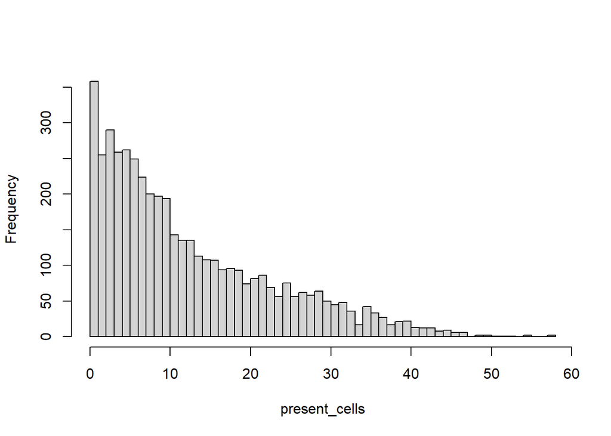

Figure 1: Histogram of the distribution of cell resistance (for a given barcode ID, returns the total number of cell lines identified).

```r
# 1) evaluation of cell resistance
present_cells <- rowSums(se_binarised_compound_batch_mat)
hist(present_cells,
     breaks = length(unique(present_cells)),
     main=NULL)

# 2) filtered Heatmaps
threshold_cell_prevalence <- 10 # alternatively, remove cells that are not present in all samples
se_binarised_compact <- se_binarised_compound_batch_mat[present_cells >
                                                             threshold_cell_prevalence, ]
cor_cell_lines <- cor(t(se_binarised_compact))
col_heatmap_scale <- circlize::colorRamp2(c(min(cor_cell_lines, na.rm = TRUE),
                                            0,
                                            max(cor_cell_lines, na.rm = TRUE)),
                                      c("blue", "white", "red"))

# 3) generate Heatmap of correlation cell lines
heatmap_cell_lines_by_cell_lines <- ComplexHeatmap::Heatmap(cor_cell_lines,
                                                        col = col_heatmap_scale,
                                                        name = "Heatmap: cell-line by cell line",
                                                        show_row_names = FALSE,
                                                        row_dend_reorder = TRUE,
                                                        show_row_dend = TRUE,
                                                        column_dend_reorder = TRUE,
                                                        show_column_names = FALSE,
                                                        na_col = "black",
                                                        use_raster = TRUE,
                                                        raster_resize_mat = mean) |>
  ComplexHeatmap::draw() |>
  grid::grid.grabExpr()

ggsave(paste0("figures/cell_lines/heatmap_cell_lines_by_cell_lines_", today_date,".pdf"),
       heatmap_cell_lines_by_cell_lines, dpi = 600, width = 20, height = 20)
```

# 6 Perspectives

## 6.1 Alternative metrics

- [Compute correlations with strongly sparse vectors?](https://www.linkedin.com/posts/%F0%9F%8E%AF-ming-tommy-tang-40650014_1-you-have-a-clear-question-is-gene-a-activity-7322971683596734464-5BqV)

## 6.2 Pair Single Cell with (or without) Drug fingerprints

- [Single cell and compound response largest database](https://www.linkedin.com/posts/independent-data-lab_check-out-the-preprint-activity-7300471798029012993-YRjy)
- [Biologist perspective](https://docs.google.com/document/d/1UHD6IG9Rti2tD77zwHfSyh5XyTbnJ25S/edit)
  - Single-cell lineage capture across genomic modalities with `CellTag-multi` reveals fate-specific gene regulatory changes -> use of **single-cell lineage-tracing (scLT)**.
  - High-resolution, noninvasive single-cell lineage tracing in mice and humans based on DNA methylation epi-mutations.
- Ming Tommy Tang lists in [Single-cell LinkedIn post](https://www.linkedin.com/posts/%F0%9F%8E%AF-ming-tommy-tang-40650014_pylemur-activity-7320442513671008256-qLJC) trendy papers and tools for multi-sample, single-cell RNAseq differential expression analysis.

### 6.2.1 Correct for Batch Effects

- [`DESeq2-MultiBatch`](https://www.biorxiv.org/content/10.1101/2025.04.20.649392v1): Batch Correction for Multi-Factorial RNA-seq Experiments, avalaible as open-source [GH repository](https://github.com/julienroyulaval/DESeq2-MultiBatch), from (**roy2025?**).

### 6.2.2 Drug-response

- [`TRADE`: Transcriptome-wide analysis of differential expression in perturbation atlases](https://www.nature.com/articles/s41588-025-02169-3), from (**nadig2025ng?**). The paper notably reports how to model a compound-dose response curve with a **Hill equation**. Avalaible as an open-source GH repository [`TRADEtools`](https://github.com/ajaynadig/TRADEtools). [R `TRADE` Tutorial](https://www.rna-seqblog.com/trade-ranscriptome-wide-analysis-of-differential-expression/)

## 6.3 Barcode Differential Analysis

### 6.3.1 `bartools` and `BARtab`

- Analysis of synthetic cellular barcodes in the genome and transcriptome with `BARtab` and `bartools`.

### 6.3.2 `DEBRA`

- Pros `DEBRA`
  - Better characterisation of the mean-variance deviation -> between `trended` or `shrinkage`, `trended` is favoured.
- Cons `DEBRA`:
  - `DEBRA` does not account for outliers expression, nor zero-inflated counts -> recommendation of `glmQLFit` and `glmQLFTest` for routine GLM-based DE analyses, from [`EdgeR`: Explaning dispersion types to newbies](https://support.bioconductor.org/p/110273/).
  - Complex protocol for discarding lowly differentially expressed barcodes.
  - No available BioConductor/CRAN Repository, while latest [`DEBRA` GitHub update](https://github.com/YevhenAkimov/DEBRA_1.01) dates back more than 4 years.

### 6.3.3 Combine Fold change and $p$-value

- [Combine statistical discernibility (aka *significance*) with practical significance](https://www.linkedin.com/posts/adrianolszewski_how-to-combine-statistical-discernibility-activity-7310365190959632384-sNHs)

## 6.4 Drug clustering and mapping

- Use of graph clustering approaches? Like Louvain? + multiple case studies, how to combine them (2 vials of cell lines)?
- Compare with ATC prediction and clustering: [`PDATC-NCPMKL-updated` GH Repo](https://github.com/Lywhere/PDATC-NCPMKL-updated).

## 7 Appendix

## 7.1 Repository organisation and Data tracking

- [Project Code Organisation](https://www.linkedin.com/posts/danleedata_become-10-better-at-machine-learning-by-activity-7320797963549564928-Au1_)
- [Data Fingerprinting with `MDA5` and Environment Snapshots: R and Code tracking](https://www.linkedin.com/posts/sebastian-rauschert-836760a0_datascience-reproducibleanalytics-commandline-activity-7312256950962896896-9JkE)
- Large datasets versioning:
  - [`DataLad` VS `DVC`](https://www.linkedin.com/posts/sebastian-rauschert-836760a0_install-datalad-activity-7307188424682127361-dJ_G)
  - [`DataLad` Versus `DVC`](https://www.linkedin.com/posts/sebastian-rauschert-836760a0_dataversioncontrol-dvc-datascience-activity-7314768876876058626-GVNF), and [`DataLad` Versus `DVC` V2](https://handbook.datalad.org/en/latest/beyond_basics/101-168-dvc.html#dvc)
  - [`Git LFS` VS `Alembic`](https://www.linkedin.com/posts/sebastian-rauschert-836760a0_reproducibility-databaseversioning-dataengineering-activity-7315522466259390466-zMun)
- [Homogenise `Excel` colnames, and other spreadsheet tips](https://www.linkedin.com/posts/%F0%9F%8E%AF-ming-tommy-tang-40650014_115-every-wet-lab-uses-spreadsheets-activity-7319725287603130368-9ILC)

## 7.2 Publish cell lines on Web repositories

- [`cellosaurus` General Comments](https://www.expasy.org/resources/cellosaurus) and [`cellosaurus` Official Website](https://www.cellosaurus.org/), from(Bairoch 2018; Robin, Capes-Davis, and Bairoch 2020). Specifically, the `CLASTR` algorithm relies on *short-tandem repeat* patterns to map user-provided cell lines with the ones available in `Cellosaurus` database.
- [`Bgee`](https://www.bgee.org/), from (Bastian et al. 2021, 2025).

## References

Bairoch, Amos. 2018. ‘The Cellosaurus, a Cell-Line Knowledge Resource’. *Journal of Biomolecular Techniques : JBT* 29 (2): 25–38. https://doi.org/10.7171/jbt.18-2902-002.

Bastian, Frederic B, Alessandro Brandulas Cammarata, Sara Carsanaro, Harald Detering, Wan-Ting Huang, Sagane Joye, Anne Niknejad, et al. 2025. ‘Bgee in 2024: Focus on Curated Single-Cell RNA-seq Datasets, and Query Tools’. *Nucleic Acids Research* 53 (D1): D878–85. https://doi.org/10.1093/nar/gkae1118.

Bastian, Frederic B, Julien Roux, Anne Niknejad, Aurélie Comte, Sara S Fonseca Costa, Tarcisio Mendes de Farias, Sébastien Moretti, et al. 2021. ‘The Bgee Suite: Integrated Curated Expression Atlas and Comparative Transcriptomics in Animals’. *Nucleic Acids Research* 49 (D1): D831–47. https://doi.org/10.1093/nar/gkaa793.

Robin, Thibault, Amanda Capes-Davis, and Amos Bairoch. 2020. ‘CLASTR: The Cellosaurus STR Similarity Search Tool - A Precious Help for Cell Line Authentication’. *International Journal of Cancer* 146 (5): 1299–1306. https://doi.org/10.1002/ijc.32639.

## Footnotes

[^1]: **Side note**: there are 532 replicates, less than the total number of rows, due to the 4 Controls shared between `exp200921` and `exp200921_dose response osim`.
[^2]: The `Warning: Detected an unexpected many-to-many relationship between x and y.` results from shared Control samples.
[^3]: Test the **Helmert contrast** to evaluate *compound dose response*, or *time-course replicates*. Also For repeated measures across time, see [One Way repeated measure ANOVA in R](https://www.r-bloggers.com/2025/02/one-way-repeated-measure-anova-in-r/)